# EE0848 Machine Learning for SP

Week 9: Neural Networks

Basri Erdogan

# Neural Networks

## Agenda

- From linear models to neural networks — the motivation
- The Perceptron: simplest neural unit
- Multilayer Perceptrons (MLPs): stacking layers
- Activation functions: why non-linearity matters
- Backpropagation: how networks learn
- Loss functions & optimizers
- Practical considerations: normalization, initialization, overfitting

## From Linear Models to Neural Networks

**Before:** Linear/Logistic Regression fits one hyperplane — $y = w^\top x + b$. Fine only if data is **linearly separable**.

**Problem:** most real patterns aren’t. Manual feature engineering doesn’t scale.

**Solution:** stack linear transforms with **non-linear activations** → the network *learns* its own features.

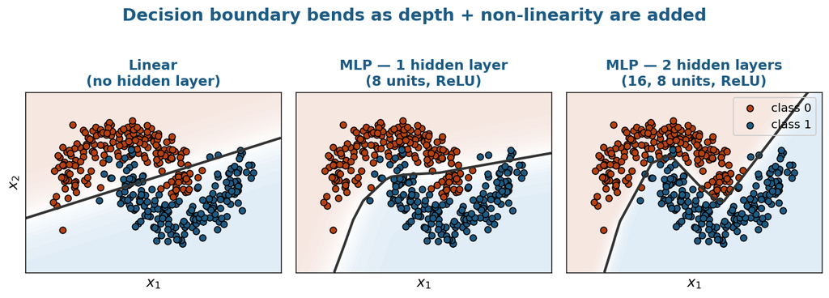

Decision boundary — Linear vs. MLPs on the moons dataset

## Why Neural Networks?

- **State-of-the-art** in vision, NLP, speech, signal processing
- **Versatile:** images, text, audio, time series
- **Automatic feature learning** — no hand-crafting
- **Scalable** with data & compute
- **Foundation** for CNNs, RNNs, Transformers

| Classical ML | Neural Networks |
| --- | --- |
| Hand-crafted features | Learned features |
| Shallow | Deep hierarchies |
| Small data OK | Needs more data |
| Interpretable | Less so |
| Fast to train | Compute-heavy |

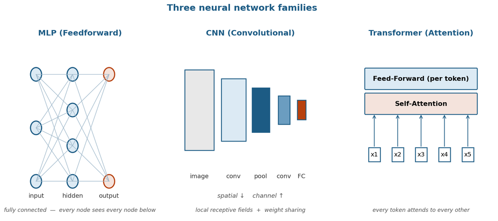

Different neural network architectures

## A Signal-Processing View

**One hidden layer = a bank of learned filters.**

For input $x \in \mathbb{R}^n$, layer 1 computes:
$$h_j = f\big(w_j^T x + b_j\big), \quad j = 1, \ldots, m$$

- Each row $w_j$ of $W_1$ is a **filter / template**
- $w_j^T x$ is an **inner product** — exactly a matched-filter response
- $f(\cdot)$ is a **non-linear detector** (threshold / rectifier)
- Depth → **hierarchical feature extraction** (cf. multi-resolution analysis)

**What’s new vs. classical SP?** The filters are **learned from data**, not hand-designed from a basis (Fourier, wavelet, Gabor…).

| Classical SP | Neural Network |
| --- | --- |
| Fixed basis (DFT, DWT) | Learned basis ($W_1$) |
| Matched filter | $w_j^T x$ + activation |
| Thresholding | ReLU / step |
| Multi-resolution | Depth / hierarchy |
| Linear + detector | Composition of both |

Neural networks **generalize** the SP toolkit: instead of choosing a filter bank, you **learn one** tailored to your task.

# The Perceptron

## The Perceptron (1958)

- **Simplest neural network** — models a single neuron
- Introduced by **Frank Rosenblatt** at Cornell
- Hardware implementation: the Mark I Perceptron

**How it works:**

1. Take inputs $x_1, x_2, \ldots, x_n$
2. Multiply each by a weight $w_i$
3. Add a bias $b$
4. Apply an activation function

$$z = \sum_{i=1}^{n} w_i x_i + b = w^T x + b$$
$$y = f(z)$$

*Look familiar?* It’s logistic regression with a different activation!

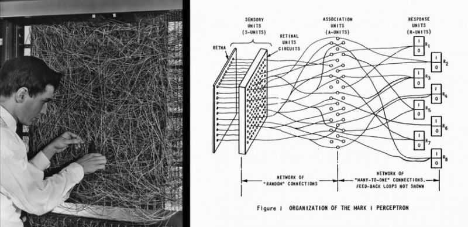

Frank Rosenblatt with the Perceptron

## Perceptron: Structure

| Component | Symbol | Role |
| --- | --- | --- |
| **Inputs** | $x_1, \ldots, x_n$ | Features |
| **Weights** | $w_1, \ldots, w_n$ | Importance of each input |
| **Bias** | $b$ | Shift the decision boundary |
| **Weighted sum** | $z = w^T x + b$ | Pre-activation |
| **Activation** | $y = f(z)$ | Output |

**Original activation:** Step function

$$f(z) = \begin{cases} 1 & \text{if } z \ge 0 \\ 0 & \text{if } z < 0 \end{cases}$$

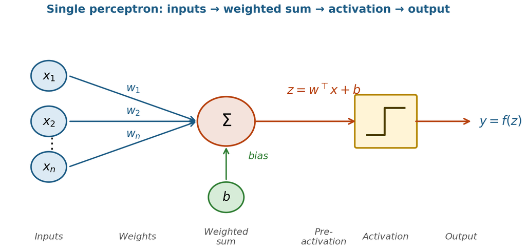

Diagram of a single Perceptron unit

## Perceptron: Learning Rule

The perceptron learns by adjusting weights based on errors:

$$w_i^{\text{new}} = w_i^{\text{old}} + \eta \cdot (y_{\text{true}} - y_{\text{pred}}) \cdot x_i$$
$$b^{\text{new}} = b^{\text{old}} + \eta \cdot (y_{\text{true}} - y_{\text{pred}})$$

| Scenario | $y_{\text{true}} - y_{\text{pred}}$ | Update |
| --- | --- | --- |
| Correct prediction | 0 | No change |
| Predicted 0, should be 1 | +1 | Increase weights |
| Predicted 1, should be 0 | −1 | Decrease weights |

- $\eta$ = **learning rate** (small step size, e.g. 0.01)
- **Convergence theorem:** if data is linearly separable, the perceptron will find a separating hyperplane in finite steps

## Perceptron: Limitations

The perceptron can only learn **linearly separable** patterns.

**The XOR problem (Minsky & Papert, 1969):**

| $x_1$ | $x_2$ | XOR |
| --- | --- | --- |
| 0 | 0 | 0 |
| 0 | 1 | 1 |
| 1 | 0 | 1 |
| 1 | 1 | 0 |

No single line can separate the 0s from the 1s!

This limitation caused the first **“AI winter”** — funding dried up because people thought neural networks were fundamentally limited.

**Solution:** stack multiple perceptrons → **Multilayer Perceptron**

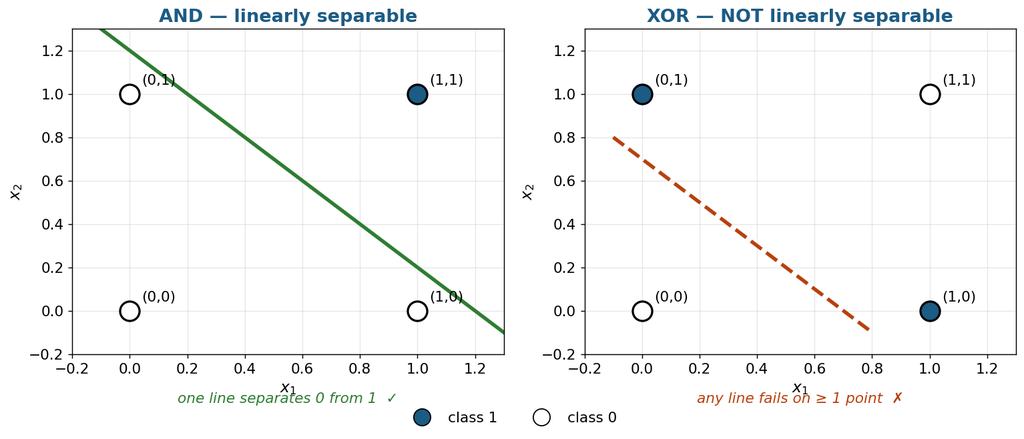

AND vs XOR separability

## Solving XOR with 2 Hidden Neurons

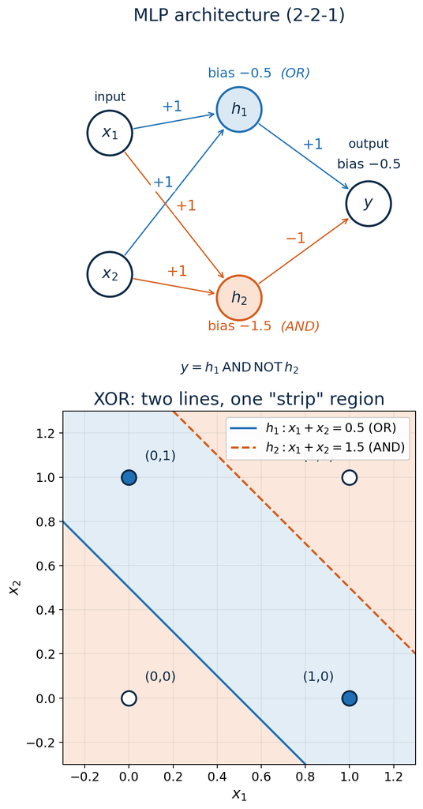

XOR = (x₁ OR x₂) AND NOT(x₁ AND x₂). **Each hidden neuron = one line.** The output combines them.

**Hidden layer** (step activation):

- $h_1 = \text{step}(x_1 + x_2 - 0.5)$ — computes **OR**
- $h_2 = \text{step}(x_1 + x_2 - 1.5)$ — computes **AND**

**Output:** $y = \text{step}(h_1 - h_2 - 0.5)$ — computes $h_1$ AND NOT $h_2$

| $x_1$ | $x_2$ | $h_1$ | $h_2$ | $y$ (XOR) |
| --- | --- | --- | --- | --- |
| 0 | 0 | 0 | 0 | **0** |
| 0 | 1 | 1 | 0 | **1** |
| 1 | 0 | 1 | 0 | **1** |
| 1 | 1 | 1 | 1 | **0** |

**Moral:** depth builds complex boundaries by **composing simple pieces**.

# Multilayer Perceptrons

## Multilayer Perceptron (MLP)

- Stack multiple layers of neurons
- **Feedforward:** Input → Hidden → Output
- Each hidden layer learns increasingly abstract features
- **Key requirement:** non-linear activation between layers — otherwise layers collapse to one linear map

*Drag the sliders →* build your own MLP and watch the parameter count scale.

[interactive chart not shown]

## MLP: The Math

For a network with one hidden layer:

**Layer 1 (Hidden):**
$$h = f_1(W_1 x + b_1)$$

**Layer 2 (Output):**
$$y = f_2(W_2 h + b_2)$$

**Full computation:**
$$y = f_2\Big(W_2 \cdot f_1(W_1 x + b_1) + b_2\Big)$$

| Symbol | Shape | Meaning |
| --- | --- | --- |
| $x$ | $(d, 1)$ | Input vector ($d$ features) |
| $W_1$ | $(h, d)$ | Hidden layer weights |
| $b_1$ | $(h, 1)$ | Hidden layer biases |
| $W_2$ | $(c, h)$ | Output layer weights |
| $f_1, f_2$ | — | Activation functions |

## Universal Approximation Theorem

> An MLP with **one hidden layer** containing enough neurons can approximate **any continuous function** to arbitrary precision.

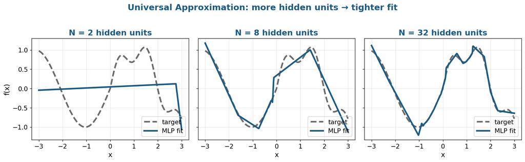

More hidden units → richer approximation. But “enough” may be astronomical.

**What it means:** NNs are universal function approximators. One hidden layer is sufficient **in theory**.

**What it doesn’t mean:** we can always *find* the right weights; a single hidden layer is *practical*; deeper isn’t better.

**Why depth helps in practice:** deep networks learn **hierarchical features** (simple → compositions → complex). Exponentially more efficient than one wide layer.

# Activation Functions

## Why Activation Functions?

**Without non-linearity, stacking layers is pointless:**

$$W_2 \cdot (W_1 x + b_1) + b_2 = (W_2 W_1) x + (W_2 b_1 + b_2) = W' x + b'$$

Two linear layers = one linear layer. **No gain from depth!**

**Requirements for a good activation function:**

| Requirement | Why |
| --- | --- |
| **Non-linear** | Enables complex decision boundaries |
| **Differentiable** | Needed for gradient-based training |
| **Efficient gradients** | Avoid vanishing/exploding gradients |
| **Computationally cheap** | Applied to every neuron, every forward pass |

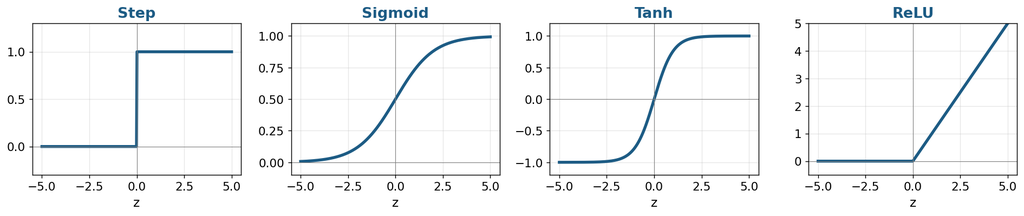

Common activation functions — Step, Sigmoid, Tanh, ReLU.

## Sigmoid

$$\sigma(z) = \frac{1}{1 + e^{-z}}$$

**Range:** $(0, 1)$ — outputs look like probabilities

**Derivative:** $\sigma'(z) = \sigma(z)(1 - \sigma(z))$

**Pros:**

- Smooth, differentiable everywhere
- Output interpretable as probability

**Cons:**

- **Vanishing gradients:** max derivative is 0.25 (at $z=0$). After several layers, gradients shrink exponentially → deep layers barely learn.
- **Not zero-centered:** outputs always positive → zig-zag gradient updates
- **Expensive:** requires `exp()` computation

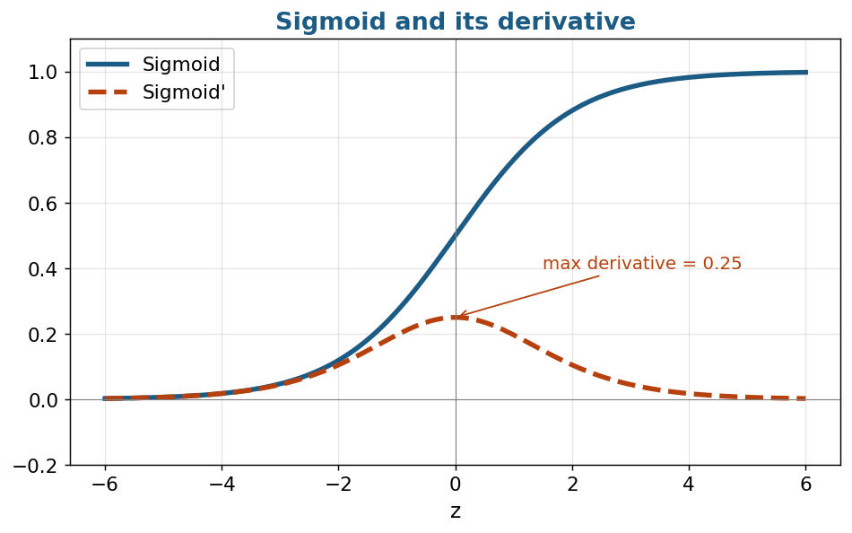

Sigmoid function and its derivative

**Use today:** output layer for **binary classification** only. Rarely in hidden layers.

## Tanh

$$\tanh(z) = \frac{e^{z} - e^{-z}}{e^{z} + e^{-z}}$$

**Range:** $(-1, 1)$ — **zero-centered**

**Derivative:** $\tanh'(z) = 1 - \tanh^2(z)$

**Pros:**

- Zero-centered → better gradient flow
- Stronger gradients than sigmoid (max derivative = 1)

**Cons:**

- Still suffers from **vanishing gradients** (saturates at extremes)
- Still requires `exp()` computation

**Relation to sigmoid:** $\tanh(z) = 2\sigma(2z) - 1$

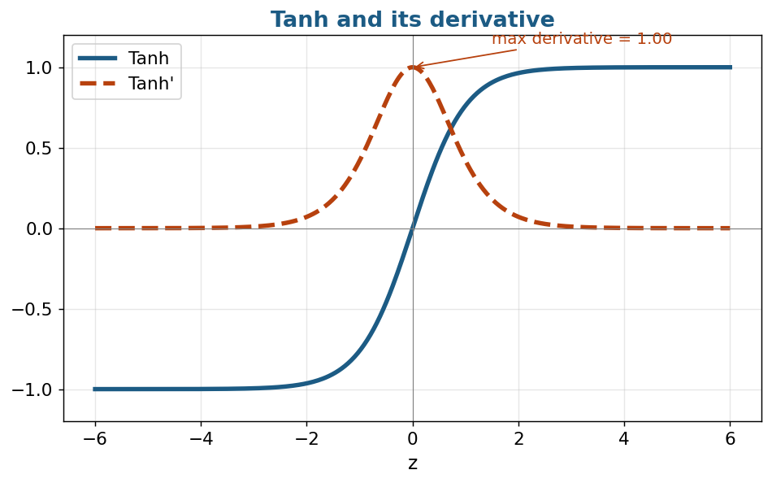

Tanh function and its derivative

**Use today:** sometimes in RNNs/LSTMs. Mostly replaced by ReLU in feedforward nets.

## ReLU: The Modern Standard

$$\text{ReLU}(z) = \max(0, z)$$

**Range:** $[0, \infty)$

**Derivative:** $\text{ReLU}'(z) = \begin{cases} 1 & z > 0 \\ 0 & z \le 0 \end{cases}$

**Pros:**

- **No vanishing gradient** for $z > 0$ (derivative = 1)
- **Computationally trivial:** just a threshold
- **Promotes sparsity:** many neurons output exactly 0
- **Fast convergence:** ~6× faster than sigmoid (Krizhevsky, 2012)

**Cons:**

- **“Dying ReLU”:** if $z < 0$ always, neuron permanently outputs 0
- Not zero-centered

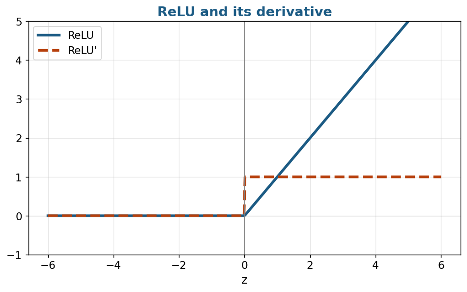

ReLU function and its derivative

## ReLU Variants

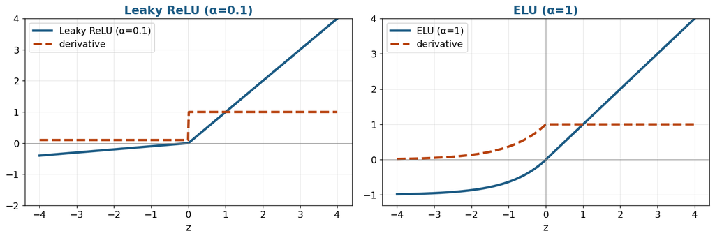

ReLU variants: Leaky ReLU and ELU

| Variant | Formula | Advantage |
| --- | --- | --- |
| **ReLU** | $\max(0, z)$ | Simple, fast, default choice |
| **Leaky ReLU** | $\max(\alpha z, z)$, $\alpha=0.01$ | No dead neurons (small negative slope) |
| **ELU** | $z$ if $z>0$, else $\alpha(e^z - 1)$ | Smooth, zero-centered for negative inputs |
| **GELU** | $z \cdot \Phi(z)$ | Smooth ReLU; default in Transformers |
| **Swish/SiLU** | $z \cdot \sigma(z)$ | Smooth, self-gated; used in modern CNNs |

**Rule of thumb:** start with ReLU. Try Leaky ReLU if you suspect dying neurons.

## Softmax: Multi-class Output

For $C$ classes with raw scores (**logits**) $z_1, \ldots, z_C$:

$$\text{softmax}(z)_i = \frac{e^{z_i}}{\sum_{j=1}^{C} e^{z_j}}$$

**Properties:**

- Each output $\in (0, 1)$, all outputs **sum to 1** → valid probability distribution
- Exponential **amplifies differences** — the largest logit dominates
- Generalizes sigmoid to $C$ classes (sigmoid is softmax with $C=2$)

**Numerical stability:** subtract the max before exponentiating:
$$\text{softmax}(z)_i = \frac{e^{z_i - \max_j z_j}}{\sum_k e^{z_k - \max_j z_j}}$$

Otherwise $e^{z_i}$ can overflow for large logits.

**Example** (3 classes, logits $z = [2, 1, 0]$):

| Class | $z_i$ | $e^{z_i}$ | softmax |
| --- | --- | --- | --- |
| 1 | 2 | 7.39 | **0.665** |
| 2 | 1 | 2.72 | 0.245 |
| 3 | 0 | 1.00 | 0.090 |

The model is most confident in class 1.

**Important**

In PyTorch, `nn.CrossEntropyLoss` applies softmax **internally** (log-sum-exp trick). Your model outputs **raw logits** — no softmax in `forward()`.

## Activation Functions: Summary

| Function | Range | Use Case | Gradient Issue? |
| --- | --- | --- | --- |
| **Step** | $\{0, 1\}$ | Original perceptron only | Not differentiable |
| **Sigmoid** | $(0, 1)$ | Output layer (binary) | Vanishing |
| **Tanh** | $(-1, 1)$ | RNNs, some hidden layers | Vanishing (less) |
| **ReLU** | $[0, \infty)$ | **Hidden layers (default)** | Dying neurons |
| **Leaky ReLU** | $(-\infty, \infty)$ | Hidden layers (if ReLU dies) | None |
| **Softmax** | $(0, 1)$, sums to 1 | Output layer (multi-class) | N/A |

**Note**

**Output layer activation depends on the task:**

- Binary classification → **Sigmoid** (or none + `BCEWithLogitsLoss`)
- Multi-class → **Softmax** (or none + `CrossEntropyLoss`)
- Regression → **None** (linear output)

# Training Neural Networks

## Loss Functions

The loss function measures how far the model’s predictions are from the true values:

| Task | Loss Function | Formula |
| --- | --- | --- |
| **Regression** | Mean Squared Error (MSE) | $L = \frac{1}{N}\sum(y - \hat{y})^2$ |
| **Binary classification** | Binary Cross-Entropy (BCE) | $L = -\frac{1}{N}\sum[y\log\hat{y} + (1-y)\log(1-\hat{y})]$ |
| **Multi-class** | Cross-Entropy | $L = -\frac{1}{N}\sum\sum y_c \log \hat{y}_c$ |

**The goal of training:** find weights $\theta = (W, b)$ that **minimize** the loss:

$$\theta^* = \arg\min_\theta L(\theta)$$

## Gradient Descent: Intuition

**Idea:** move weights in the direction that decreases the loss

$$\theta^{\text{new}} = \theta^{\text{old}} - \eta \cdot \nabla_\theta L$$

- $\nabla_\theta L$ = gradient (direction of steepest increase)
- $\eta$ = learning rate (step size)
- We go **opposite** to the gradient → downhill

**Learning rate matters:**

| $\eta$ too small | $\eta$ too large |
| --- | --- |
| Very slow convergence | Overshoots, diverges |
| May get stuck in bad local minima | Loss oscillates or increases |
| Safe but wasteful | Fast but unstable |

**Variants:**

| Method | Batch Size | Trade-off |
| --- | --- | --- |
| **Batch GD** | All data | Stable but slow |
| **SGD** | 1 sample | Fast but noisy |
| **Mini-batch SGD** | 32–256 | Best of both |

Mini-batch SGD is the standard in practice — fast updates with reasonable gradient estimates.

## Backpropagation: How NNs Learn

**Problem:** we need $\frac{\partial L}{\partial w}$ for every weight in the network.

**Backpropagation** computes all gradients efficiently using the **chain rule**:

$$\frac{\partial L}{\partial w} = \frac{\partial L}{\partial y} \cdot \frac{\partial y}{\partial z} \cdot \frac{\partial z}{\partial w}$$

**The process:**

1. **Forward pass:** compute predictions layer by layer
2. **Compute loss:** compare prediction to target
3. **Backward pass:** propagate gradients from output back to input
4. **Update:** adjust weights using the gradients

[figure not shown]

Reference MLP

[figure not shown]

The backpropagation algorithm

## Chain Rule: Worked Example

**Setup:** single neuron, weight $w$, bias $b=0$, sigmoid activation, squared error loss.

$$x \xrightarrow{w} z = wx \xrightarrow{\sigma} y = \sigma(z) \xrightarrow{L} L = \tfrac{1}{2}(y - y_{\text{true}})^2$$

**Chain rule:**
$$\frac{\partial L}{\partial w} = \underbrace{\frac{\partial L}{\partial y}}_{y - y_{\text{true}}} \cdot \underbrace{\frac{\partial y}{\partial z}}_{\sigma'(z) = y(1-y)} \cdot \underbrace{\frac{\partial z}{\partial w}}_{x}$$

**Numerical example:** $x = 2$, $w = 0.5$, $y_{\text{true}} = 1$

| Step | Computation | Value |
| --- | --- | --- |
| Forward: $z$ | $0.5 \times 2$ | 1.0 |
| Forward: $y$ | $\sigma(1.0)$ | 0.731 |
| Forward: $L$ | $\frac{1}{2}(0.731 - 1)^2$ | 0.036 |
| Backward: $\frac{\partial L}{\partial w}$ | $(0.731 - 1) \times 0.731(1-0.731) \times 2$ | −0.106 |

*Gradient is negative → increase $w$ to decrease loss.*

## Backpropagation: Code

**Forward pass:**

```python
import numpy as np

def sigmoid(z):
    return 1 / (1 + np.exp(-z))

# Layer 1 (Hidden)
z1 = np.dot(X, W1) + b1
a1 = sigmoid(z1)

# Layer 2 (Output)
z2 = np.dot(a1, W2) + b2
a2 = sigmoid(z2)

# Error
error = a2 - y  # (prediction - target)
```

**Backward pass + update:**

```python
def sigmoid_deriv(a):
    return a * (1 - a)

# Output layer gradients
# Shortcut: sigmoid' * BCE' telescopes to (y_hat - y).
# For MSE or other losses you MUST multiply by sigmoid_deriv(a2).
delta2 = error
grad_W2 = np.dot(a1.T, delta2)
grad_b2 = np.sum(delta2, axis=0)

# Hidden layer gradients
delta1 = np.dot(delta2, W2.T) * sigmoid_deriv(a1)
grad_W1 = np.dot(X.T, delta1)
grad_b1 = np.sum(delta1, axis=0)

# Update parameters
W1 -= lr * grad_W1;  b1 -= lr * grad_b1
W2 -= lr * grad_W2;  b2 -= lr * grad_b2
```

**Note**

In practice, **you never write this manually.** PyTorch’s autograd does it automatically — just call `loss.backward()`.

## Optimizers: Beyond Basic SGD

| Optimizer | Update Rule | Key Feature |
| --- | --- | --- |
| **SGD** | $\theta \gets \theta - \eta \nabla L$ | Simple baseline |
| **SGD + Momentum** | $v \gets \beta v + \nabla L$; $\theta \gets \theta - \eta v$ | Smooths updates, accelerates |
| **RMSprop** | Adapts LR per-parameter by gradient magnitude | Handles different scales |
| **Adam** | Momentum + adaptive LR (1st + 2nd moment) | Most popular default |
| **AdamW** | Adam + decoupled weight decay | Better generalization |

**Adam** is the default choice for most tasks: combines momentum + adaptive LR; works well “out of the box” with $\text{lr} = 10^{-3}$.

## Optimizers: A Picture

[figure not shown]

## The Vanishing Gradient Problem

**Problem:** gradients shrink exponentially as they flow backward through many layers.

For a network with $L$ layers using sigmoid ($\sigma'_{\max} = 0.25$):

$$\frac{\partial L}{\partial w_1} \propto \prod_{l=1}^{L} \sigma'(z_l) \le 0.25^L$$

| Layers | Max gradient factor |
| --- | --- |
| 2 | $0.25^2 = 0.0625$ |
| 5 | $0.25^5 \approx 0.001$ |
| 10 | $0.25^{10} \approx 10^{-6}$ |

**Early layers stop learning!**

**Solutions:** ReLU (derivative = 1 for $z>0$), Batch Normalization, skip connections (ResNet), proper init (He / Xavier), gradient clipping.

## Vanishing Gradient: Simulation

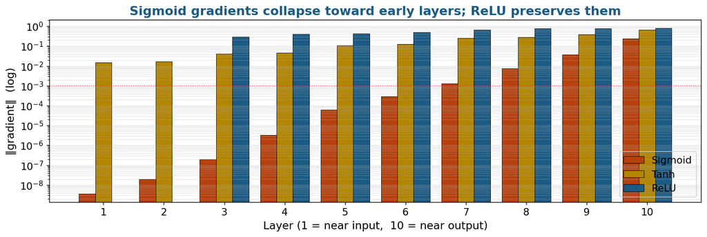

# Practical Considerations

## Data Normalization

Scale input features so they’re on a comparable range:

| Method | Formula | Result |
| --- | --- | --- |
| **Min-Max** | $x' = \frac{x - \min}{\max - \min}$ | Scale to $[0, 1]$ |
| **Standardization** | $x' = \frac{x - \mu}{\sigma}$ | Scale to $\mu=0, \sigma=1$ |

**Why it matters for neural networks:**

- Unscaled features → some weights get huge gradients, others get tiny ones
- Optimizer struggles to find a good learning rate for all weights
- Standardized data → loss landscape is more **spherical** → easier optimization

Fit the scaler on **training data only!** Apply the same transform to validation/test. Otherwise you leak future information.

## Weight Initialization

How you set the initial weights matters enormously:

**Why not zeros?** All neurons compute the same thing → all get the same gradient → all stay the same. **Symmetry is never broken.**

**Why not large random?** Activations saturate → vanishing gradients from the start.

| Strategy | Formula | Best for |
| --- | --- | --- |
| **Small random** | $N(0, 0.01)$ | Simple, but often suboptimal |
| **Xavier / Glorot** | $\sigma = \sqrt{\frac{2}{n_{\text{in}} + n_{\text{out}}}}$ | Sigmoid, Tanh |
| **He (Kaiming)** | $\sigma = \sqrt{\frac{2}{n_{\text{in}}}}$ | **ReLU** (default in PyTorch) |

- $n_{\text{in}}$: number of inputs to the layer
- **Biases:** initialized to **zero** (asymmetry comes from weights)

## Overfitting in Neural Networks

Neural networks have **millions of parameters** — they can memorize the training data.

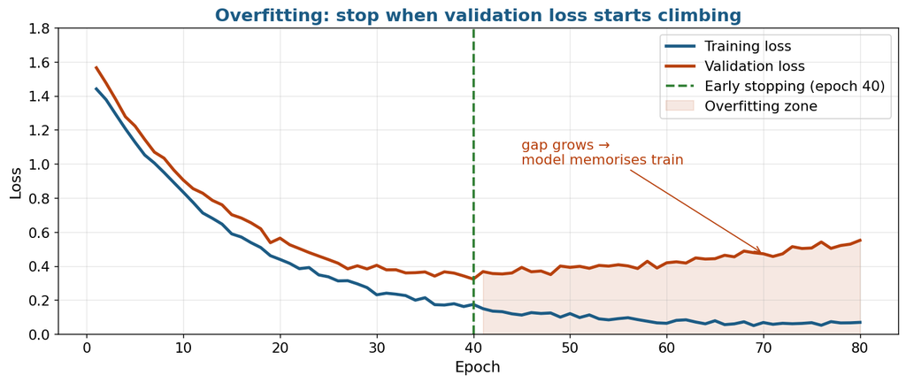

Training loss keeps falling, validation turns back up — stop at the green line.

**Signs:** training loss ↓, validation loss ↑, growing gap.

**Remedies:**

| Technique | How it helps |
| --- | --- |
| **More data** | Best solution |
| **Dropout** | Zero random neurons |
| **Weight decay (L2)** | Shrinks weights |
| **Early stopping** | Stop at val-loss min |
| **Data augmentation** | More effective data |
| **Batch norm** | Slight regularization |
| **Smaller model** | Fewer parameters |

## Summary

- **Perceptron:** single neuron, linear decision boundary, can’t solve XOR
- **MLP:** stack layers + non-linear activations → can approximate any function
- **Activation functions:** ReLU is the default for hidden layers; sigmoid/softmax for output
- **Backpropagation:** chain rule applied backward through the network → gradients for all weights
- **Training:** loss function + optimizer (Adam) + mini-batch SGD
- **Practical:** normalize data, initialize weights properly, watch for overfitting

## Next Week

**Convolutional Neural Networks (CNNs):**

- Specialized architecture for **grid-structured data** (images, spectrograms, signals)
- Exploit **locality** and **weight sharing** for massive parameter savings
- Building blocks: Conv → BN → ReLU → Pool
- Training with PyTorch end-to-end

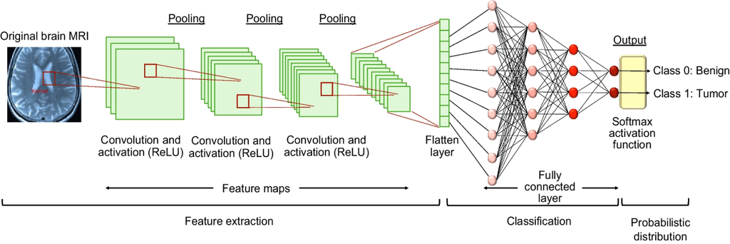